# Analyzing Individual BGG Users

Phil Henrickson

2022-01-02

# **Aazatgrabya’s** BoardGameGeek Collection

This notebook contains a set of analyses for the selected user’s boardgamegeek collection. The bulk of the analysis is focused on building a user-specific predictive model to predict the games that Aazatgrabya is likely to own. This enables to ask questions like, based on the games the user currently owns, what games are a good fit for their collection? What upcoming games are they likely to purchase?

This analysis is based on data from BoardGameGeek that was last updated on **2021-12-20.**

# 1 Collection Overview

We can look at a basic description of the number of games that the user owns, has rated, has previously owned, etc.

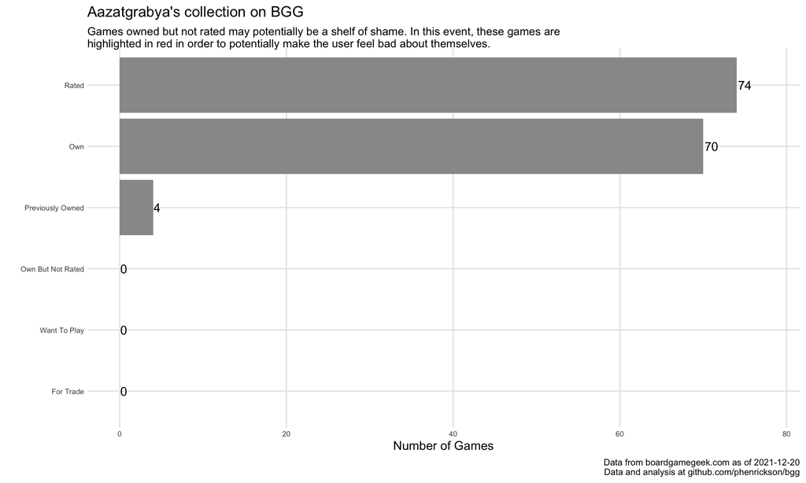

What years has the user owned/rated games from? While we can’t see when a user added or removed a game from their collection, we can look at their collection by the years in which their games were published.

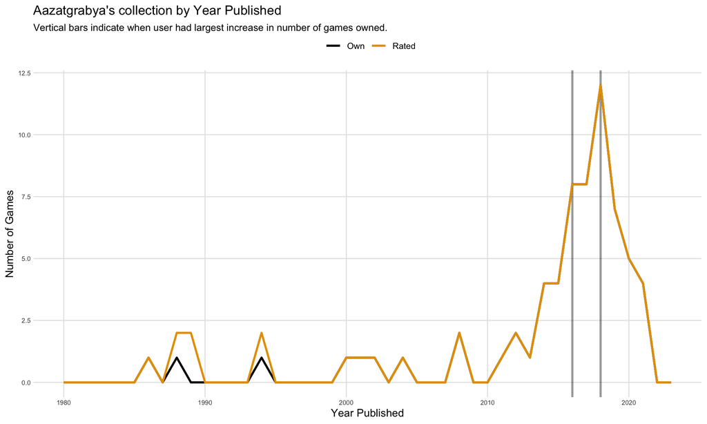

## 1.1 What types of games does Aazatgrabya own?

We can look at the most frequent types of categories, mechanics, designers, and artists that appear in a user’s collection.

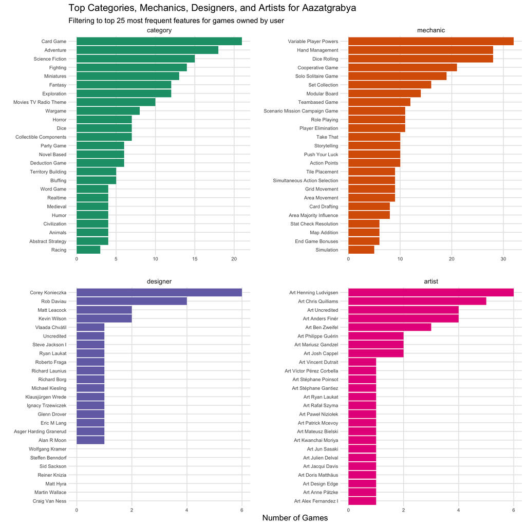

# 2 Modeling **Aazatgrabya’s** Collection

| username | dataset | period | games_owned | games_rated | games_played |
| --- | --- | --- | --- | --- | --- |
| Aazatgrabya | training | published before 2020 | 54 | 58 | 58 |
| Aazatgrabya | test | published 2020 or later | 9 | 9 | 9 |

There are two main (binary) outcomes we will be modeling for the user.

The first, **own** refers to whether the user currently lists a game as owned in their collection. The second, **played** refers to whether the user currently owns, has rated, or previously owned a game. This means the latter will generally have a larger list of games, but may still be a useful category to examine for people who play lots of games without necessarily owning them.

We will train predictive models to learn the probability that the user will own or play individual games based on their features.

## 2.1 Coefficients for Aazatgrabya

We can examine coefficients from the trained modes, which are penalized logistic regressions fit to our two main outcomes. Positive values indicate that a feature increases a user’s probabilility of owning/rating a game, while negative values indicate a feature decreases the probability.

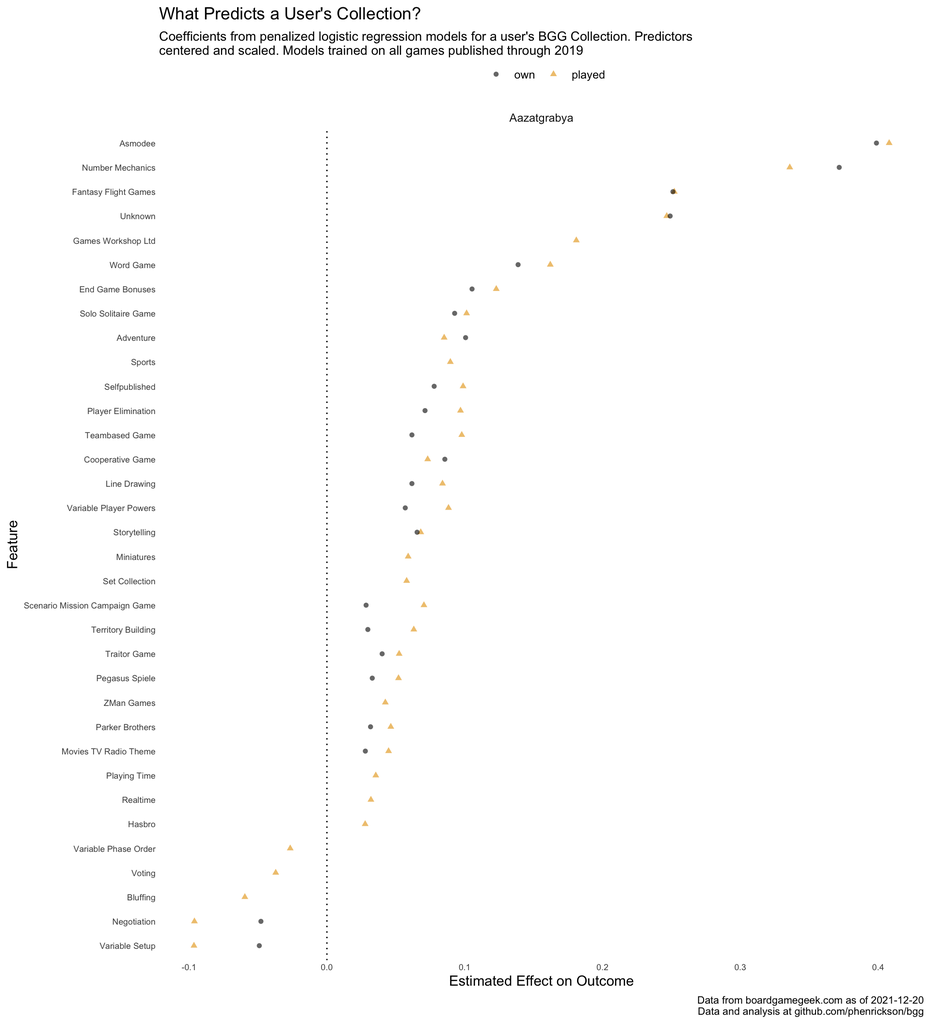

## 2.2 Visualizing Predictors for Aazatgrabya’s Collection

Why did the model identify these features? We can make density plots of the important features for predicting whether the user owned a game. Blue indicates the density for games owned by the user, while grey indicates the density for games not owned by the user.

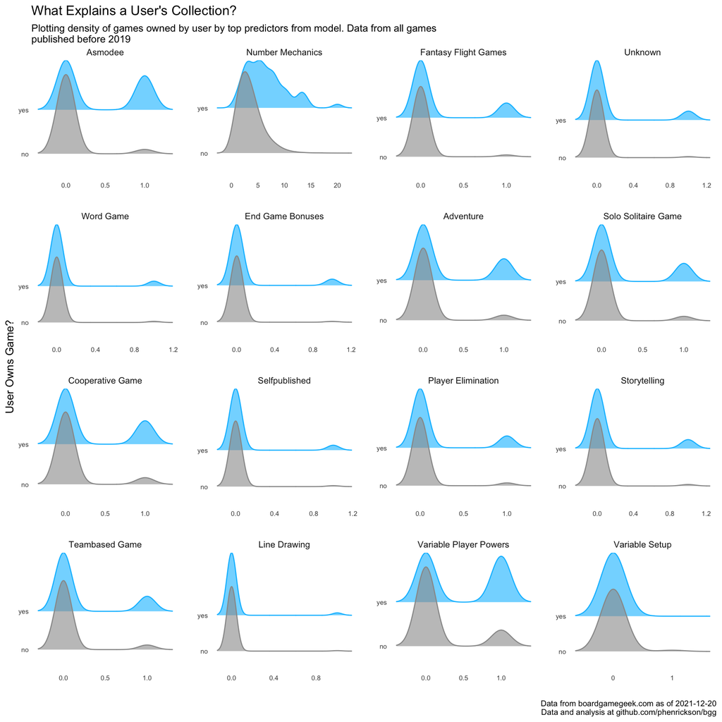

Binary predictors can be difficult to see with this visualization, so we can also directly examine the percentage of games in a user’s collection with a predictor vs the percentage of all games with that predictor.

| username | Feature | % of Games with Feature In_Collection | % of Games with Feature All_Games | Ratio |
| --- | --- | --- | --- | --- |
| Aazatgrabya | Unknown | 13.0% | 1.4% | 9.1 |
| Aazatgrabya | Traitor Game | 5.6% | 0.7% | 8.5 |
| Aazatgrabya | Fantasy Flight Games | 20.4% | 2.5% | 8.0 |
| Aazatgrabya | Asmodee | 40.7% | 5.2% | 7.9 |
| Aazatgrabya | End Game Bonuses | 9.3% | 1.2% | 7.4 |
| Aazatgrabya | Storytelling | 13.0% | 2.2% | 6.0 |
| Aazatgrabya | Scenario Mission Campaign Game | 13.0% | 2.3% | 5.6 |
| Aazatgrabya | Realtime | 3.7% | 0.7% | 5.4 |
| Aazatgrabya | Selfpublished | 7.4% | 1.4% | 5.3 |
| Aazatgrabya | Line Drawing | 3.7% | 0.7% | 5.2 |
| Aazatgrabya | Word Game | 7.4% | 1.7% | 4.3 |
| Aazatgrabya | Adventure | 27.8% | 6.5% | 4.2 |
| Aazatgrabya | Player Elimination | 16.7% | 4.0% | 4.2 |
| Aazatgrabya | Solo Solitaire Game | 24.1% | 5.8% | 4.1 |
| Aazatgrabya | Cooperative Game | 29.6% | 8.5% | 3.5 |
| Aazatgrabya | Teambased Game | 20.4% | 6.3% | 3.3 |
| Aazatgrabya | Parker Brothers | 9.3% | 2.9% | 3.1 |
| Aazatgrabya | Variable Player Powers | 48.1% | 16.9% | 2.9 |
| Aazatgrabya | Movies TV Radio Theme | 11.1% | 3.9% | 2.9 |
| Aazatgrabya | Pegasus Spiele | 13.0% | 4.7% | 2.7 |
| Aazatgrabya | Territory Building | 9.3% | 3.6% | 2.6 |
| Aazatgrabya | Bluffing | 3.7% | 6.8% | 0.5 |
| Aazatgrabya | Variable Setup | 0.0% | 1.9% | 0.0 |
| Aazatgrabya | Negotiation | 0.0% | 3.7% | 0.0 |
| Aazatgrabya | Voting | 0.0% | 2.5% | 0.0 |

# 3 Assess Model’s Performance on Training Set

Before predicting games in upcoming years, we can examine how well the model did and what games it liked in the training set. In this case, we used resampling techniques (cross validation) to ensure that the model had not seen a game before making its predictions.

## 3.1 Separation Plot

An easy way to examine the performance of classification model is to view a separation plot. We plot the predicted probabilities from the model for every game (from resampling) from lowest to highest. We then overlay a blue line for any game that the user does own. A good classifier is one that is able to *separate* the blue (games owned by the user) from the white (games not owned by the user), with most of the blue occurring at the highest probabilities (right side of the chart).

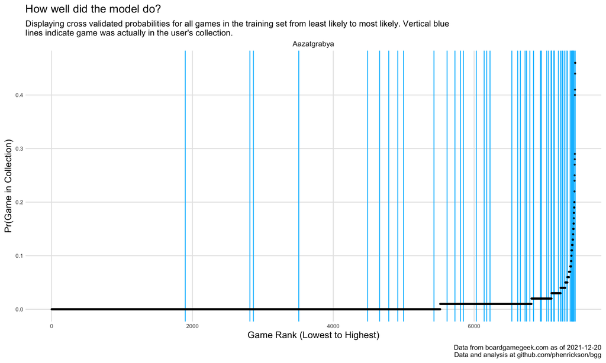

## 3.2 Top Games for **Aazatgrabya** from Training Set

We can display this information in table form, displaying the 100 games with the highest probability of ownership, adding a blue line when the user does own the game.

| username | yearpublished | game_id | name | pred_played | pred_own | actual_played | actual_own |
| --- | --- | --- | --- | --- | --- | --- | --- |
| Aazatgrabya | 2004 | 10547 | Betrayal at House on the Hill | 0.21 | 0.46 | 0 | 0 |
| Aazatgrabya | 2019 | 269385 | The Lord of the Rings: Journeys in Middle-Earth | 0.41 | 0.46 | 1 | 1 |
| Aazatgrabya | 2017 | 233078 | Twilight Imperium: Fourth Edition | 0.33 | 0.44 | 0 | 0 |
| Aazatgrabya | 2017 | 232918 | Fallout | 0.35 | 0.41 | 0 | 0 |
| Aazatgrabya | 2018 | 254591 | Heroes of Terrinoth | 0.23 | 0.40 | 0 | 0 |
| Aazatgrabya | 2016 | 205398 | Citadels | 0.24 | 0.29 | 0 | 0 |
| Aazatgrabya | 2017 | 174430 | Gloomhaven | 0.32 | 0.28 | 1 | 1 |
| Aazatgrabya | 2018 | 205896 | Rising Sun | 0.17 | 0.27 | 0 | 0 |
| Aazatgrabya | 2000 | 478 | Citadels | 0.16 | 0.25 | 0 | 0 |
| Aazatgrabya | 2011 | 70919 | Takenoko | 0.27 | 0.24 | 0 | 0 |
| Aazatgrabya | 2009 | 56885 | The Werewolves of Miller's Hollow: The Village | 0.18 | 0.22 | 0 | 0 |
| Aazatgrabya | 2019 | 266507 | Clank!: Legacy – Acquisitions Incorporated | 0.24 | 0.20 | 0 | 0 |
| Aazatgrabya | 2010 | 62219 | Dominant Species | 0.26 | 0.20 | 0 | 0 |
| Aazatgrabya | 2010 | 73439 | Troyes | 0.16 | 0.19 | 0 | 0 |
| Aazatgrabya | 2005 | 15987 | Arkham Horror | 0.17 | 0.19 | 0 | 0 |
| Aazatgrabya | 2005 | 21523 | Runebound: Second Edition | 0.21 | 0.19 | 0 | 0 |
| Aazatgrabya | 2015 | 172242 | Exploding Kittens: NSFW Deck | 0.55 | 0.19 | 0 | 0 |
| Aazatgrabya | 2011 | 96848 | Mage Knight Board Game | 0.15 | 0.18 | 0 | 0 |
| Aazatgrabya | 2006 | 14808 | Marvel Heroes | 0.13 | 0.18 | 0 | 0 |
| Aazatgrabya | 1900 | 15878 | Rummy | 0.20 | 0.18 | 0 | 0 |
| Aazatgrabya | 2005 | 18723 | Aye, Dark Overlord! The Red Box | 0.23 | 0.17 | 0 | 0 |
| Aazatgrabya | 2019 | 283863 | The Magnificent | 0.16 | 0.16 | 0 | 0 |
| Aazatgrabya | 2012 | 121921 | Robinson Crusoe: Adventures on the Cursed Island | 0.28 | 0.16 | 0 | 0 |
| Aazatgrabya | 2017 | 188920 | This War of Mine: The Board Game | 0.19 | 0.16 | 1 | 1 |
| Aazatgrabya | 2019 | 264220 | Tainted Grail: The Fall of Avalon | 0.06 | 0.15 | 0 | 0 |
| Aazatgrabya | 2019 | 276025 | Maracaibo | 0.09 | 0.15 | 0 | 0 |
| Aazatgrabya | 2008 | 37111 | Battlestar Galactica: The Board Game | 0.06 | 0.15 | 0 | 0 |
| Aazatgrabya | 2012 | 131357 | Coup | 0.39 | 0.15 | 0 | 0 |
| Aazatgrabya | 2012 | 104162 | Descent: Journeys in the Dark (Second Edition) | 0.13 | 0.15 | 1 | 1 |
| Aazatgrabya | 2016 | 205716 | New Angeles | 0.19 | 0.14 | 0 | 0 |

[output cut: 70 more lines]

We can also more formally assess how well the model did in resampling by looking at the area under the receiver operating characteristic. A perfect model would receive a score of 1, while a model that cannot predict the outcome will default to a score of 0.5. The extent to which something is a *good* score depends on the setting, but generally anything in the .8 to .9 range is very good while the .7 to .8 range is perfectly acceptable.

| username | outcome_type | .metric | .estimator | .estimate |
| --- | --- | --- | --- | --- |
| Aazatgrabya | own | roc_auc | binary | 0.851 |
| Aazatgrabya | played | roc_auc | binary | 0.845 |

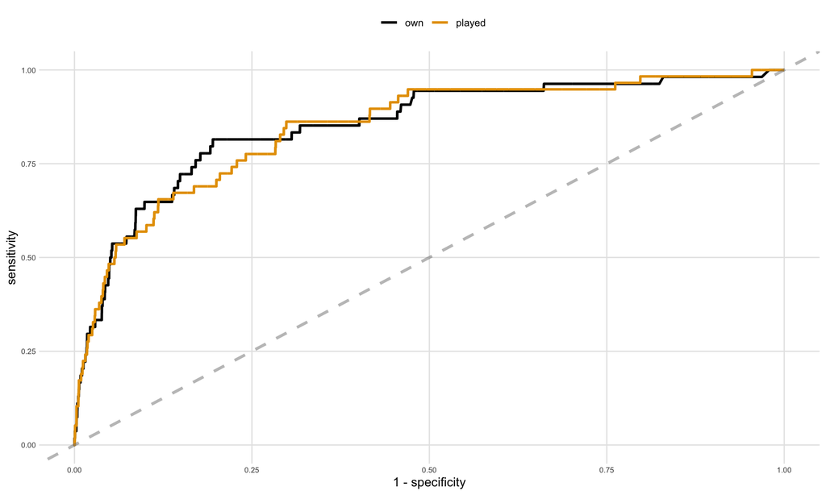

Another way to think about the model performance is to view its lift, or its ability to detect the positive outcomes over that of a null model. High lift indicates the model can much more quickly find all of the positive outcomes (in this case, games owned or played by the user), while a model with no lift is no better than random guessing.

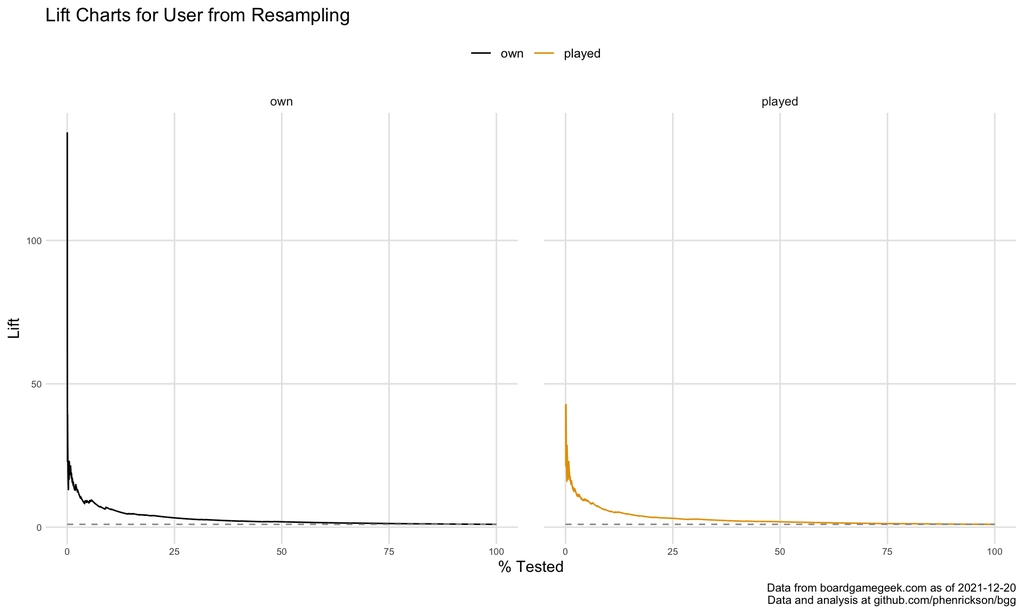

## 3.3 Most and Least Likely Games

What games does the model think Aazatgrabya is **most likely to own** that are **not** in their collection?

| username | yearpublished | game_id | name | pred_own | actual_own |
| --- | --- | --- | --- | --- | --- |
| Aazatgrabya | 2004 | 10547 | Betrayal at House on the Hill | 0.46 | 0 |
| Aazatgrabya | 2017 | 233078 | Twilight Imperium: Fourth Edition | 0.44 | 0 |
| Aazatgrabya | 2017 | 232918 | Fallout | 0.41 | 0 |
| Aazatgrabya | 2018 | 254591 | Heroes of Terrinoth | 0.40 | 0 |
| Aazatgrabya | 2016 | 205398 | Citadels | 0.29 | 0 |

What games does the model think Aazatgrabya is **least likely to own** that **are** in their collection?

| username | yearpublished | game_id | name | pred_own | actual_own |
| --- | --- | --- | --- | --- | --- |
| Aazatgrabya | 2016 | 199478 | Flamme Rouge | 0 | 1 |
| Aazatgrabya | 1988 | 943 | Ligretto | 0 | 1 |
| Aazatgrabya | 2018 | 260300 | Dungeon Mayhem | 0 | 1 |
| Aazatgrabya | 2002 | 3633 | Sid Meier's Civilization: The Boardgame | 0 | 1 |
| Aazatgrabya | 2018 | 246759 | You've Got Crabs | 0 | 1 |

## 3.4 Top Games by Year

Top 25 games most likely to be owned by the user in each year, highlighting in blue the games that the user has owned/played.

| rank | 2011 | 2012 | 2013 | 2014 | 2015 | 2016 | 2017 | 2018 | 2019 |
| --- | --- | --- | --- | --- | --- | --- | --- | --- | --- |
| 1 | Takenoko | Robinson Crusoe: Adventures on the Cursed Island | Room 25 | Star Wars: Imperial Assault | Exploding Kittens: NSFW Deck | Citadels | Twilight Imperium: Fourth Edition | Heroes of Terrinoth | The Lord of the Rings: Journeys in Middle-Earth |
| 2 | Mage Knight Board Game | Coup | BANG! The Dice Game | HINT | March of the Ants | New Angeles | Fallout | Rising Sun | Clank!: Legacy – Acquisitions Incorporated |
| 3 | Flash Point: Fire Rescue | Descent: Journeys in the Dark (Second Edition) | Eldritch Horror | DungeonQuest Revised Edition | 504 | Hit Z Road | Gloomhaven | Arkham Horror (Third Edition) | The Magnificent |
| 4 | Mansions of Madness | Zombicide | Lewis & Clark: The Expedition | Hyperborea | Zombicide Season 3: Rue Morgue | Mansions of Madness: Second Edition | This War of Mine: The Board Game | Lords of Hellas | Tainted Grail: The Fall of Avalon |
| 5 | Letters from Whitechapel | Space Cadets | Warhammer: Diskwars | Patchwork | Bang! The Dice Game: The Walking Dead | Black Orchestra | Codenames: Duet | Zombicide: Green Horde | Maracaibo |
| 6 | Eclipse | Mice and Mystics | Zombicide Season 2: Prison Outbreak | Arcadia Quest | Bastion | Codenames: Deep Undercover | Summit: The Board Game | Star Wars: Legion | Star Wars: Outer Rim |
| 7 | A Game of Thrones: The Board Game (Second Edition) | Wiz-War (Eighth Edition) | Forbidden Desert | Witness | Runebound (Third Edition) | Pandemic: Reign of Cthulhu | Photosynthesis | The Order of Vampire Hunters | Last Bastion |
| 8 | Elder Sign | Keyflower | Nations | Akrotiri | Warhammer Quest: The Adventure Card Game | Sherlock Holmes Consulting Detective: Jack the Ripper & West End Adventures | Breaking Bad: The Board Game | Gingerbread House | Era: Medieval Age |
| 9 | A Few Acres of Snow | Escape: The Curse of the Temple | BattleLore: Second Edition | Black Fleet | Salem 1692 | Game of Thrones: The Iron Throne | Massive Darkness | Shadows: Amsterdam | Spire's End |
| 10 | Ventura | Legends of Andor | Pizza Party | The Witcher Adventure Game | Fury of Dracula (Third/Fourth Edition) | Scythe | Whitehall Mystery | Pandemic: Fall of Rome | Paranormal Detectives |
| 11 | Gears of War: The Board Game | Il Vecchio | Firefly: The Game | Colt Express | T.I.M.E Stories | Mistfall: Heart of the Mists | Pandemic Legacy: Season 2 | Century: Eastern Wonders | Call to Adventure |
| 12 | Rune Age | Libertalia | Anomia: Party Edition | Bucket of Doom | Burgle Bros. | When I Dream | Civilization: A New Dawn | Azul: Stained Glass of Sintra | Aftermath |
| 13 | Dungeon Fighter | Archipelago | Funemployed | Pandemic: The Cure | Blood Rage | 1572: The Lost Expedition | Unstable Unicorns | The World of SMOG: Rise of Moloch | Pandemic: Rapid Response |
| 14 | The Adventurers: The Pyramid of Horus | Serenissima (Second Edition) | Dungeon Twister: The Card Game | Gaïa | Kingdom Death: Monster | Harry Potter: Hogwarts Battle | The Godfather: Corleone's Empire | Kero | Sierra West |
| 15 | Saga | Freedom: The Underground Railroad | Rivet Wars: Eastern Front | Dead of Winter: A Crossroads Game | Forbidden Stars | The Others | Word Domination | Stuffed Fables | Century: A New World |
| 16 | Blood Bowl: Team Manager – The Card Game | Love Letter | Pathfinder Adventure Card Game: Rise of the Runelords – Base Set | Star Wars: Empire vs. Rebellion | Risk: Europe | Clank!: A Deck-Building Adventure | Spirit Island | Underwater Cities | Zombicide: Invader |
| 17 | Dixit: Odyssey | Winter Tales | Relic | Castles of Mad King Ludwig | Mafia de Cuba | Star Wars: Rebellion | Unlock!: Escape Adventures – Fifth Avenue | Vengeance | KeyForge: Age of Ascension |
| 18 | Rory's Story Cubes: Voyages | Rex: Final Days of an Empire | Berserk: War of the Realms | Deus | Mysterium | Agricola (Revised Edition) | Exploding Kittens: Party Pack | Discover: Lands Unknown | Arkham Horror: Final Hour |
| 19 | Panic Station | Terra Mystica | Prosperity | Abyss | Drakon (Fourth Edition) | Avenue | Runewars Miniatures Game | Pax Emancipation | Black Angel |
| 20 | Québec | Tokaido | Corto | Assault on Doomrock | Tiny Epic Galaxies | Bloodborne: The Card Game | Raging Bulls | Western Legends | Unlock!: Epic Adventures |
| 21 | Dungeons & Dragons: The Legend of Drizzt Board Game | Kemet | Gearworld: The Borderlands | Splendor | Exploding Kittens | Dead of Winter: The Long Night | Gaia Project | Warhammer Quest: Blackstone Fortress | Cartographers |
| 22 | Evo (Second Edition) | Agents of SMERSH | Patchistory | Chosŏn | The Pursuit of Happiness | Aventuria: Adventure Card Game | Azul | Newton | Yggdrasil Chronicles |
| 23 | Ascension: Return of the Fallen | Seasons | Cappuccino | Camel Up | Thunderbirds | Star Trek: Frontiers | A Tale of Pirates | Gen7: A Crossroads Game | The King's Dilemma |
| 24 | Drako: Dragon & Dwarves | Divinare | Ultimate Werewolf: Inquisition | Stay Away! | Barony | Behind the Throne | Secrets | Fireball Island: The Curse of Vul-Kar | Zona: The Secret of Chernobyl |
| 25 | Streams | The Last Banquet | Concept | Deception: Murder in Hong Kong | XCOM: The Board Game | Android: Mainframe | Codenames: Disney – Family Edition | Street Masters | God of War: The Card Game |

## 3.5 Interactive Predictions from Resampling

Interactive table for predictions from resampling.

|  | username | yearpublished | rank | game_id | name | pred_played | pred_own | actual_played | actual_own |
| --- | --- | --- | --- | --- | --- | --- | --- | --- | --- |
| 1 | Aazatgrabya | 1900 | 20 | 15878 | Rummy | 0.2 | 0.18 | 0 | 0 |
| 2 | Aazatgrabya | 1900 | 50 | 45 | Perudo | 0.29 | 0.11 | 1 | 1 |
| 3 | Aazatgrabya | 1900 | 92 | 7316 | Bingo | 0.06 | 0.06 | 0 | 0 |
| 4 | Aazatgrabya | 1900 | 142 | 188 | Go | 0.02 | 0.04 | 0 | 0 |
| 5 | Aazatgrabya | 1900 | 143 | 171 | Chess | 0.03 | 0.04 | 0 | 0 |
| 6 | Aazatgrabya | 1900 | 144 | 2065 | Shogi | 0.02 | 0.04 | 0 | 0 |
| 7 | Aazatgrabya | 1900 | 170 | 2173 | 4 Player Chess | 0.03 | 0.04 | 0 | 0 |
| 8 | Aazatgrabya | 1900 | 174 | 21389 | Happy Families | 0.03 | 0.04 | 0 | 0 |
| 9 | Aazatgrabya | 1900 | 183 | 17003 | Snap | 0.02 | 0.04 | 0 | 0 |
| 10 | Aazatgrabya | 1900 | 191 | 2386 | Chinese Checkers | 0.04 | 0.04 | 0 | 0 |

[output cut: 7426 more lines]

# 4 Validating the Model on 2020

How well did a model trained on a user’s collection through 2019 perform in predicting games for the user from 2020?

| username | outcome_type | yearpublished | .metric | .estimator | .estimate |
| --- | --- | --- | --- | --- | --- |
| Aazatgrabya | own | 2020 | roc_auc | binary | 0.745 |
| Aazatgrabya | played | 2020 | roc_auc | binary | 0.763 |

Table of top 25 games from 2020, highlighting games that the user owns.

| username | yearpublished | game_id | name | pred_own | pred_played | actual_own | actual_played |
| --- | --- | --- | --- | --- | --- | --- | --- |
| Aazatgrabya | 2020 | 291457 | Gloomhaven: Jaws of the Lion | 0.37 | 0.47 | 0 | 0 |
| Aazatgrabya | 2020 | 298572 | Cosmic Encounter Duel | 0.10 | 0.08 | 0 | 0 |
| Aazatgrabya | 2020 | 302723 | Forgotten Waters | 0.09 | 0.10 | 0 | 0 |
| Aazatgrabya | 2020 | 184267 | On Mars | 0.08 | 0.08 | 0 | 0 |
| Aazatgrabya | 2020 | 316554 | Dune: Imperium | 0.07 | 0.07 | 0 | 0 |
| Aazatgrabya | 2020 | 293889 | Fallout Shelter: The Board Game | 0.06 | 0.05 | 0 | 0 |
| Aazatgrabya | 2020 | 256317 | Guild Master | 0.05 | 0.04 | 0 | 0 |
| Aazatgrabya | 2020 | 287742 | TIME Stories Revolution: The Hadal Project | 0.05 | 0.05 | 0 | 0 |
| Aazatgrabya | 2020 | 304434 | Victim: The Cursed Forest | 0.05 | 0.08 | 0 | 0 |
| Aazatgrabya | 2020 | 271524 | TIME Stories Revolution: A Midsummer Night | 0.04 | 0.04 | 0 | 0 |
| Aazatgrabya | 2020 | 282922 | Windward | 0.04 | 0.04 | 0 | 0 |
| Aazatgrabya | 2020 | 291874 | Dwergar | 0.04 | 0.05 | 0 | 0 |
| Aazatgrabya | 2020 | 292333 | Cowboys II: Cowboys & Indians Edition | 0.04 | 0.03 | 0 | 0 |
| Aazatgrabya | 2020 | 301767 | Mysterium Park | 0.04 | 0.04 | 0 | 0 |
| Aazatgrabya | 2020 | 302425 | Unlock!: Mythic Adventures | 0.04 | 0.04 | 0 | 0 |
| Aazatgrabya | 2020 | 302465 | Obsidia | 0.04 | 0.03 | 0 | 0 |
| Aazatgrabya | 2020 | 312267 | Star Wars: Unlock! | 0.04 | 0.03 | 0 | 0 |
| Aazatgrabya | 2020 | 314040 | Pandemic Legacy: Season 0 | 0.04 | 0.05 | 0 | 0 |
| Aazatgrabya | 2020 | 246900 | Eclipse: Second Dawn for the Galaxy | 0.03 | 0.03 | 0 | 0 |
| Aazatgrabya | 2020 | 262274 | D6: Dungeons, Dudes, Dames, Danger, Dice and Dragons! | 0.03 | 0.03 | 0 | 0 |
| Aazatgrabya | 2020 | 266188 | Seven Bridges | 0.03 | 0.04 | 0 | 0 |
| Aazatgrabya | 2020 | 294235 | Crime Zoom: His Last Card | 0.03 | 0.03 | 0 | 0 |
| Aazatgrabya | 2020 | 296151 | Viscounts of the West Kingdom | 0.03 | 0.03 | 0 | 0 |
| Aazatgrabya | 2020 | 296345 | Sherlock Holmes Consulting Detective: The Baker Street Irregulars | 0.03 | 0.02 | 0 | 0 |
| Aazatgrabya | 2020 | 298352 | The Shining | 0.03 | 0.03 | 0 | 0 |

# 5 Predicting Upcoming Games (2020 and On) for **Aazatgrabya**

Examine the top games for the test set.

| username | yearpublished | game_id | name | rank | own | played |
| --- | --- | --- | --- | --- | --- | --- |
| Aazatgrabya | 2020 | 291457 | Gloomhaven: Jaws of the Lion | 1 | 0.37 | 0.47 |
| Aazatgrabya | 2020 | 298572 | Cosmic Encounter Duel | 2 | 0.10 | 0.08 |
| Aazatgrabya | 2020 | 302723 | Forgotten Waters | 3 | 0.09 | 0.10 |
| Aazatgrabya | 2020 | 184267 | On Mars | 4 | 0.08 | 0.08 |
| Aazatgrabya | 2020 | 316554 | Dune: Imperium | 5 | 0.07 | 0.07 |
| Aazatgrabya | 2020 | 293889 | Fallout Shelter: The Board Game | 6 | 0.06 | 0.05 |
| Aazatgrabya | 2020 | 256317 | Guild Master | 7 | 0.05 | 0.04 |
| Aazatgrabya | 2020 | 287742 | TIME Stories Revolution: The Hadal Project | 8 | 0.05 | 0.05 |
| Aazatgrabya | 2020 | 304434 | Victim: The Cursed Forest | 9 | 0.05 | 0.08 |
| Aazatgrabya | 2020 | 312267 | Star Wars: Unlock! | 10 | 0.04 | 0.03 |
| Aazatgrabya | 2020 | 282922 | Windward | 11 | 0.04 | 0.04 |
| Aazatgrabya | 2020 | 302425 | Unlock!: Mythic Adventures | 12 | 0.04 | 0.04 |
| Aazatgrabya | 2020 | 302465 | Obsidia | 13 | 0.04 | 0.03 |
| Aazatgrabya | 2020 | 301767 | Mysterium Park | 14 | 0.04 | 0.04 |
| Aazatgrabya | 2020 | 271524 | TIME Stories Revolution: A Midsummer Night | 15 | 0.04 | 0.04 |
| Aazatgrabya | 2020 | 291874 | Dwergar | 16 | 0.04 | 0.05 |
| Aazatgrabya | 2020 | 292333 | Cowboys II: Cowboys & Indians Edition | 17 | 0.04 | 0.03 |
| Aazatgrabya | 2020 | 314040 | Pandemic Legacy: Season 0 | 18 | 0.04 | 0.05 |
| Aazatgrabya | 2020 | 316750 | The Princess Bride Adventure Book Game | 19 | 0.03 | 0.04 |
| Aazatgrabya | 2020 | 296345 | Sherlock Holmes Consulting Detective: The Baker Street Irregulars | 20 | 0.03 | 0.02 |
| Aazatgrabya | 2020 | 327913 | Unlock!: Timeless Adventures – Arsène Lupin und der große weiße Diamant | 21 | 0.03 | 0.02 |
| Aazatgrabya | 2020 | 332229 | Unlock!: Heroic Adventures – Hinunter in den Kaninchenbau | 22 | 0.03 | 0.02 |
| Aazatgrabya | 2020 | 332230 | Unlock!: Heroic Adventures – Insert Coin | 23 | 0.03 | 0.02 |
| Aazatgrabya | 2020 | 341008 | Unlock!: Heroic Adventures – Sherlock Holmes: Der scharlachrote Faden | 24 | 0.03 | 0.02 |
| Aazatgrabya | 2020 | 323367 | Outsmarted! | 25 | 0.03 | 0.03 |
| Aazatgrabya | 2021 | 340466 | Unfathomable | 1 | 0.22 | 0.27 |
| Aazatgrabya | 2021 | 322708 | Descent: Legends of the Dark | 2 | 0.12 | 0.14 |
| Aazatgrabya | 2021 | 273330 | Bloodborne: The Board Game | 3 | 0.09 | 0.10 |
| Aazatgrabya | 2021 | 285967 | Ankh: Gods of Egypt | 4 | 0.09 | 0.12 |
| Aazatgrabya | 2021 | 310873 | Carnegie | 5 | 0.08 | 0.08 |
| Aazatgrabya | 2021 | 298102 | Roll Camera!: The Filmmaking Board Game | 6 | 0.07 | 0.08 |
| Aazatgrabya | 2021 | 340237 | Wonder Book | 7 | 0.06 | 0.06 |
| Aazatgrabya | 2021 | 251661 | Oathsworn: Into the Deepwood | 8 | 0.05 | 0.05 |
| Aazatgrabya | 2021 | 340909 | Gloomholdin' | 9 | 0.05 | 0.05 |
| Aazatgrabya | 2021 | 290236 | Canvas | 10 | 0.04 | 0.03 |
| Aazatgrabya | 2021 | 319263 | One Card Dungeon | 11 | 0.04 | 0.04 |
| Aazatgrabya | 2021 | 299566 | Batman: The Animated Series Adventures – Shadow of the Bat | 12 | 0.04 | 0.04 |
| Aazatgrabya | 2021 | 284653 | Mind MGMT: The Psychic Espionage “Game.” | 13 | 0.04 | 0.04 |
| Aazatgrabya | 2021 | 347137 | Chronicles of Avel | 14 | 0.04 | 0.03 |
| Aazatgrabya | 2021 | 342848 | World of Warcraft: Wrath of the Lich King | 15 | 0.04 | 0.06 |
| Aazatgrabya | 2021 | 343905 | Boonlake | 16 | 0.03 | 0.03 |
| Aazatgrabya | 2021 | 239189 | Chronicle X | 17 | 0.03 | 0.04 |
| Aazatgrabya | 2021 | 312904 | Conan the Cimmerian: The Tower of the Elephant | 18 | 0.03 | 0.02 |
| Aazatgrabya | 2021 | 295785 | Euthia: Torment of Resurrection | 19 | 0.03 | 0.02 |
| Aazatgrabya | 2021 | 291859 | Riftforce | 20 | 0.03 | 0.02 |
| Aazatgrabya | 2021 | 288385 | Masters of the Night | 21 | 0.03 | 0.03 |
| Aazatgrabya | 2021 | 262201 | Sword & Sorcery: Ancient Chronicles | 22 | 0.03 | 0.04 |
| Aazatgrabya | 2021 | 260789 | Assassin's Creed: Brotherhood of Venice | 23 | 0.03 | 0.04 |
| Aazatgrabya | 2021 | 282776 | Tumble Town | 24 | 0.03 | 0.05 |
| Aazatgrabya | 2021 | 310100 | Nemesis: Lockdown | 25 | 0.03 | 0.04 |
| Aazatgrabya | 2022 | 331106 | The Witcher: Old World | 1 | 0.16 | 0.14 |
| Aazatgrabya | 2022 | 317511 | Tindaya | 2 | 0.12 | 0.13 |
| Aazatgrabya | 2022 | 322524 | Bardsung | 3 | 0.10 | 0.10 |
| Aazatgrabya | 2022 | 295770 | Frosthaven | 4 | 0.08 | 0.11 |
| Aazatgrabya | 2022 | 304051 | Creature Comforts | 5 | 0.06 | 0.08 |
| Aazatgrabya | 2022 | 273814 | Deliverance | 6 | 0.05 | 0.06 |
| Aazatgrabya | 2022 | 317321 | Darkest Dungeon: The Board Game | 7 | 0.04 | 0.05 |
| Aazatgrabya | 2022 | 311823 | Nova Aetas Renaissance | 8 | 0.04 | 0.05 |
| Aazatgrabya | 2022 | 340325 | Vagrantsong | 9 | 0.03 | 0.02 |
| Aazatgrabya | 2022 | 256680 | Return to Dark Tower | 10 | 0.03 | 0.02 |
| Aazatgrabya | 2022 | 280726 | Legacies | 11 | 0.03 | 0.03 |
| Aazatgrabya | 2022 | 295374 | Long Shot: The Dice Game | 12 | 0.02 | 0.03 |
| Aazatgrabya | 2022 | 284118 | Mechanical Beast | 13 | 0.02 | 0.02 |
| Aazatgrabya | 2022 | 299106 | Fractal: Beyond the Void | 14 | 0.02 | 0.02 |
| Aazatgrabya | 2022 | 281258 | Sub Terra II: Inferno's Edge | 15 | 0.02 | 0.01 |
| Aazatgrabya | 2022 | 293941 | Mage Noir | 16 | 0.02 | 0.02 |
| Aazatgrabya | 2022 | 319807 | Shogun no Katana | 17 | 0.02 | 0.02 |
| Aazatgrabya | 2022 | 324090 | Scarface 1920 | 18 | 0.02 | 0.02 |
| Aazatgrabya | 2022 | 277025 | Vampire: The Masquerade – CHAPTERS | 19 | 0.02 | 0.02 |
| Aazatgrabya | 2022 | 335427 | Wild: Serengeti | 20 | 0.02 | 0.03 |
| Aazatgrabya | 2022 | 283137 | Human Punishment: The Beginning | 21 | 0.02 | 0.02 |
| Aazatgrabya | 2022 | 274471 | Malhya: Lands of Legends | 22 | 0.02 | 0.03 |
| Aazatgrabya | 2022 | 305096 | Endless Winter: Paleoamericans | 23 | 0.02 | 0.03 |
| Aazatgrabya | 2022 | 331401 | Dog Park | 24 | 0.01 | 0.00 |
| Aazatgrabya | 2022 | 294529 | Entropia: The Game | 25 | 0.01 | 0.00 |

## 5.1 Interactive Table for Upcoming Games 2020 and On

|  | username | yearpublished | game_id | name | rank | own | played |
| --- | --- | --- | --- | --- | --- | --- | --- |
| 1 | Aazatgrabya | 2020 | 291457 | Gloomhaven: Jaws of the Lion | 1 | 0.37 | 0.47 |
| 2 | Aazatgrabya | 2021 | 340466 | Unfathomable | 2 | 0.22 | 0.27 |
| 3 | Aazatgrabya | 2022 | 331106 | The Witcher: Old World | 3 | 0.16 | 0.14 |
| 4 | Aazatgrabya | 2021 | 322708 | Descent: Legends of the Dark | 4 | 0.12 | 0.14 |
| 5 | Aazatgrabya | 2022 | 317511 | Tindaya | 5 | 0.12 | 0.13 |
| 6 | Aazatgrabya | 2020 | 298572 | Cosmic Encounter Duel | 6 | 0.1 | 0.08 |
| 7 | Aazatgrabya | 2022 | 322524 | Bardsung | 7 | 0.1 | 0.1 |
| 8 | Aazatgrabya | 2020 | 302723 | Forgotten Waters | 8 | 0.09 | 0.1 |
| 9 | Aazatgrabya | 2021 | 273330 | Bloodborne: The Board Game | 9 | 0.09 | 0.1 |
| 10 | Aazatgrabya | 2021 | 285967 | Ankh: Gods of Egypt | 10 | 0.09 | 0.12 |

[output cut: 1627 more lines]